# Cost of Living (Prices) by Country

Supervised Learning Regression Model

Dataset: January 10, 2025 10:20 PM

Source: https://www.numbeo.com/cost-of-living/prices_by_country Methodology & Motivation: https://www.numbeo.com/common/motivation_and_methodology.jsp

```python
# Give Google Colab access to your Google Drive
from google.colab import drive
drive.mount('/content/drive')
```

## Context

The dataset contains global cost-of-living indicators for various countries. It includes details like food, transportation, education, and other expenses, reflecting each country's economic standing and affordability. This information can be useful for people relocating, governments, economists, or businesses to analyze and compare living standards globally

## Objective

Conduct a Supervised Regresssion Prediction to Re-Rank the Countries based on features representing desirability.

To build a regression model that predicts the "Rank" of countries based on the cost of living metrics (e.g., food prices, education costs, transportation costs). This prediction can help identify which countries have similar living standards and their affordability ranking. Additionally, insights can be used to group countries into tiers or assess affordability trends globally.

Target: Rank (lower rank means higher desirability)

```python
#Import Basic Libraries
import pandas as pd
import numpy as np

# Adjust Pandas options to display all columns
pd.set_option('display.max_columns', None)
pd.set_option('display.max_rows', None)
```

## Dataset Description

- Release Date: January 10, 2025 10:30 PM, CST
- Currency: USD
- Columns: Multiple Products and Types

Some Columns:

Cost of Living Index (Excl. Rent):

- This index indicates the relative prices of consumer goods like groceries, restaurants, transportation, and utilities.
- It excludes accommodation expenses such as rent or mortgage.
- For instance, a city with a Cost of Living Index of 120 is estimated to be 20% more expensive than New York City (excluding rent).

Rent Index:

- This index estimates the prices of renting apartments in a city compared to New York City.
- If the Rent Index is 80, it suggests that the average rental prices in that city are approximately 20% lower than those in New York City.

Groceries Index:

- This index provides an estimation of grocery prices in a city relative to New York City. Numbeo uses item weights from the "Markets" section to calculate this index for each city.
- Restaurants Index: This index compares the prices of meals and drinks in restaurants and bars to those in NYC.

Cost of Living Plus Rent Index:

- This index estimates consumer goods prices, including rent, in comparison to New York City.
- Local Purchasing Power: This index indicates the relative purchasing power in a given city based on the average net salary.
- A domestic purchasing power of 40 means that residents with an average salary can afford, on average, 60% less goods and services compared to residents of New York City with an average salary.

## Scrape the Data

### Loading/Importing the Dataset

```python
data = pd.read_csv('/content/drive/MyDrive/My DS DA/Cost of Living Country Comparison/cost_living.csv', index_col = None)
df = data.copy()
```

```python
df.sample(5, random_state = 0)
```

|  | Rank | Country | Meal, Inexpensive Restaurant | Meal for 2 People, Mid-range Restaurant, Three-course | McMeal at McDonalds (or Equivalent Combo Meal) | Domestic Beer (0.5 liter draught) | Imported Beer (0.33 liter bottle) | Coke/Pepsi (0.33 liter bottle) | Water (0.33 liter bottle) | Milk (regular), (1 liter) | Loaf of Fresh White Bread (500g) | Eggs (regular) (12) | Local Cheese (1kg) | Water (1.5 liter bottle) | Bottle of Wine (Mid-Range) | Domestic Beer (0.5 liter bottle) | Imported Beer (0.33 liter bottle)_1 | Cigarettes 20 Pack (Marlboro) | One-way Ticket (Local Transport) | Chicken Fillets (1kg) | Monthly Pass (Regular Price) | Gasoline (1 liter) | Volkswagen Golf 1.4 90 KW Trendline (Or Equivalent New Car) | Apartment (1 bedroom) in City Centre | Apartment (1 bedroom) Outside of Centre | Apartment (3 bedrooms) in City Centre | Apartment (3 bedrooms) Outside of Centre | Basic (Electricity, Heating, Cooling, Water, Garbage) for 85m2 Apartment | Internet (60 Mbps or More, Unlimited Data, Cable/ADSL) | … |
| --- | --- | --- | --- | --- | --- | --- | --- | --- | --- | --- | --- | --- | --- | --- | --- | --- | --- | --- | --- | --- | --- | --- | --- | --- | --- | --- | --- | --- | --- | --- |
| 26 | 27 | Sweden | 12.08 | 71.59 | 9.40 | 6.71 | 6.44 | 2.29 | 1.96 | 1.43 | 2.61 | 3.74 | 10.24 | 1.29 | 8.95 | 1.79 | 1.85 | 6.44 | 3.31 | 10.63 | 74.72 | 1.69 | 27652.37 | 846.60 | 641.19 | 1394.36 | 1048.41 | 107.97 | 31.00 | … |
| 84 | 85 | Tunisia | 3.12 | 18.70 | 4.68 | 1.56 | 2.10 | 0.60 | 0.26 | 0.45 | 0.16 | 1.47 | 9.65 | 0.28 | 6.23 | 1.18 | 1.24 | 3.12 | 0.31 | 5.52 | 9.35 | 0.79 | 37409.67 | 208.76 | 138.44 | 357.87 | 241.52 | 49.11 | 19.52 | … |
| 2 | 3 | Belgium | 20.57 | 82.29 | 10.29 | 4.63 | 4.11 | 2.82 | 2.52 | 1.16 | 2.16 | 3.49 | 13.50 | 0.93 | 7.71 | 1.71 | 2.02 | 9.77 | 2.57 | 10.54 | 50.40 | 1.73 | 29674.72 | 859.57 | 745.23 | 1308.40 | 1093.38 | 197.34 | 51.97 | … |
| 55 | 56 | Chile | 7.95 | 44.71 | 7.45 | 2.98 | 3.97 | 1.35 | 1.03 | 1.11 | 1.45 | 3.38 | 9.95 | 1.11 | 4.97 | 1.35 | 2.11 | 4.97 | 0.75 | 5.67 | 38.25 | 1.30 | 15895.57 | 430.26 | 350.45 | 764.27 | 610.00 | 109.80 | 20.87 | … |
| 68 | 69 | Oman | 5.20 | 25.98 | 7.79 | 11.69 | 11.33 | 0.84 | 0.31 | 1.81 | 1.15 | 2.45 | 4.93 | 0.55 | 19.48 | 4.45 | 9.00 | 5.97 | 1.30 | 5.54 | 58.45 | 0.62 | 22729.04 | 555.22 | 355.13 | 940.05 | 627.99 | 98.61 | 73.35 | … |

```python
df.shape
```

```
(96, 57)
```

Observations

- Multple Columns including Rank (preset form data)
- 96 rows and 57 columns

Some columns will not be needed

## Checking the Information

### .shape()

```python
df.shape
```

### .info()

```python
df.info()
```

```
<class 'pandas.core.frame.DataFrame'>
RangeIndex: 96 entries, 0 to 95
Data columns (total 57 columns):
 #   Column                                                                      Non-Null Count  Dtype
---  ------                                                                      --------------  -----
 0   Rank                                                                        96 non-null     int64
 1   Country                                                                     96 non-null     object
 2   Meal, Inexpensive Restaurant                                                96 non-null     float64
 3   Meal for 2 People, Mid-range Restaurant, Three-course                       96 non-null     float64
 4   McMeal at McDonalds (or Equivalent Combo Meal)                              96 non-null     float64
 5   Domestic Beer (0.5 liter draught)                                           96 non-null     object
 6   Imported Beer (0.33 liter bottle)                                           96 non-null     object
 7   Coke/Pepsi (0.33 liter bottle)                                              96 non-null     float64
 8   Water (0.33 liter bottle)                                                   96 non-null     float64
 9   Milk (regular), (1 liter)                                                   96 non-null     float64
```

[output cut: 49 more lines]

Column: Rank will need to be removed as this is the target

```python
df.dtypes.value_counts()
```

|  | count |
| --- | --- |
| float64 | 50 |
| object | 6 |
| int64 | 1 |

**dtype:** int64

int

- Integer 1 dtype
  - Rank: Target Variable
- object * 6 dtypes
- float * 50 dtypes

```python
df.select_dtypes('object').columns.to_list()
```

```
['Country',
 'Domestic Beer (0.5 liter draught)',
 'Imported Beer (0.33 liter bottle)',
 'Bottle of Wine (Mid-Range)',
 'Domestic Beer (0.5 liter bottle)',
 'Imported Beer (0.33 liter bottle)_1']
```

```python
df.select_dtypes(include = 'object').head(1)
```

|  | Country | Domestic Beer (0.5 liter draught) | Imported Beer (0.33 liter bottle) | Bottle of Wine (Mid-Range) | Domestic Beer (0.5 liter bottle) | Imported Beer (0.33 liter bottle)_1 |
| --- | --- | --- | --- | --- | --- | --- |
| 0 | Switzerland | 7.67 | 6.57 | 13.14 | 2.25 | 2.65 |

ALl excluding 'Country' can be changed to float dtype.

```python
# List of columns to convert
from_ob_to_float_col = ['Domestic Beer (0.5 liter draught)',
 'Imported Beer (0.33 liter bottle)',
 'Bottle of Wine (Mid-Range)',
 'Domestic Beer (0.5 liter bottle)',
 'Imported Beer (0.33 liter bottle)_1']

# Convert columns to float using apply
df[from_ob_to_float_col] = df[from_ob_to_float_col].apply(pd.to_numeric, errors = 'coerce')
```

```python
df.select_dtypes('object').columns.to_list()
```

```
['Country']
```

```python
# verify

df.dtypes.value_counts()
```

|  | count |
| --- | --- |
| float64 | 55 |
| int64 | 1 |
| object | 1 |

**dtype:** int64

### Missing Data

```python
# # df.isnull()
#df.isnull().sum()
df.isnull().sum().sum()
```

```
35
```

```python
# List of columns with missing values
df.columns[df.isnull().any()].to_list()
```

```
['Domestic Beer (0.5 liter draught)',
 'Imported Beer (0.33 liter bottle)',
 'Bottle of Wine (Mid-Range)',
 'Domestic Beer (0.5 liter bottle)',
 'Imported Beer (0.33 liter bottle)_1']
```

Each column has 7 missing values

```python
# # Display rows with missing values
# df[df.isnull().any(axis = 1)] # .any(axis=1): Checks if any value in a row is missing
```

```python
# df_null_try = df.copy()

# # Create a copy so original is not changed & can compare
# domestic_beer_before = df_null_try['Domestic Beer (0.5 liter draught)'].copy() # Null values

# # Methods to observe replacing na values for P_Xylene

# import pandas as pd
# import matplotlib.pyplot as plt

# # Assuming your DataFrame is called df_null_try
# domestic_beer_before = df_null_try['Domestic Beer (0.5 liter draught)'].copy()  # Copy of the original column

# # Create columns with different NaN handling methods using domestic_beer_before
# domestic_beer_before_bfill = domestic_beer_before.fillna(method='bfill')  # Backward fill
# domestic_beer_before_ffill = domestic_beer_before.fillna(method='ffill')  # Forward fill
# domestic_beer_before_interpolation = domestic_beer_before.interpolate(method='linear')  # Linear interpolation
# domestic_beer_before_mean = domestic_beer_before.fillna(domestic_beer_before.mean())  # Fill with mean
# domestic_beer_before_mode = domestic_beer_before.fillna(domestic_beer_before.mode()[0])  # Fill with mode

# # Plot the original and filled data
# plt.figure(figsize=(20, 10))
# df_null_try['Domestic Beer (0.5 liter draught)'].plot(label='Original', linewidth=2, linestyle='--', color='blue')
# domestic_beer_before_bfill.plot(label='Backward Fill', linestyle='-', color='red', alpha=0.8)
# domestic_beer_before_ffill.plot(label='Forward Fill', linestyle='-', color='green', alpha=0.8)
# domestic_beer_before_interpolation.plot(label='Interpolation', linestyle=':', color='orange', alpha=0.8)
# domestic_beer_before_mean.plot(label='Mean Fill', linestyle='-.', color='purple', alpha=0.8)
# domestic_beer_before_mode.plot(label='Mode Fill', linestyle='-', color='brown', alpha=0.8)

# # Customize the plot
# plt.title('Comparison of Missing Data Handling Methods for Domestic Beer (0.5 liter draught)')
# plt.xlabel('Index')
# plt.ylabel('Domestic Beer (0.5 liter draught)')
# plt.legend()
# plt.grid()
# plt.show()
# plt.tight_layout();
```

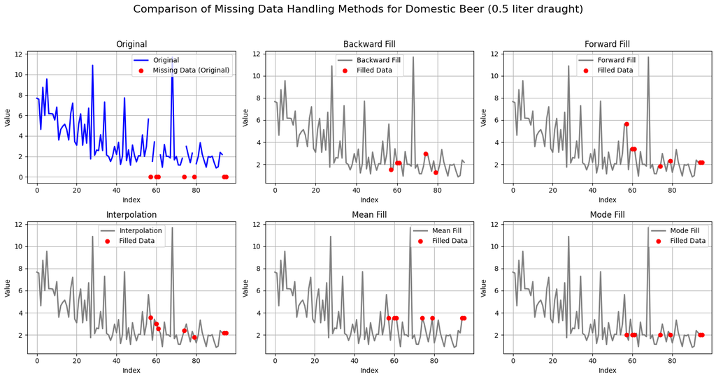

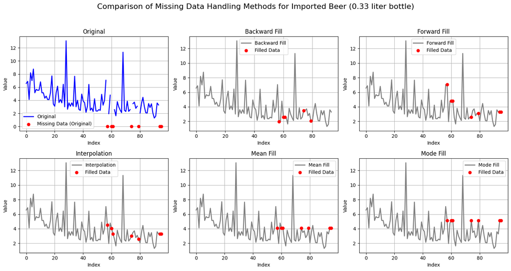

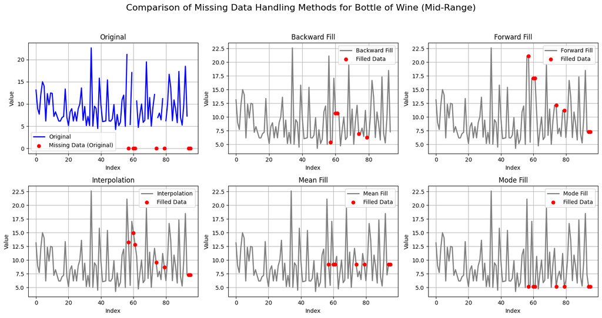

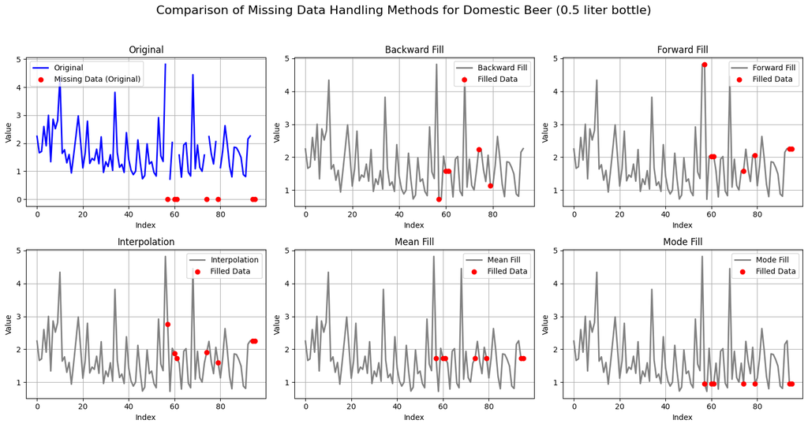

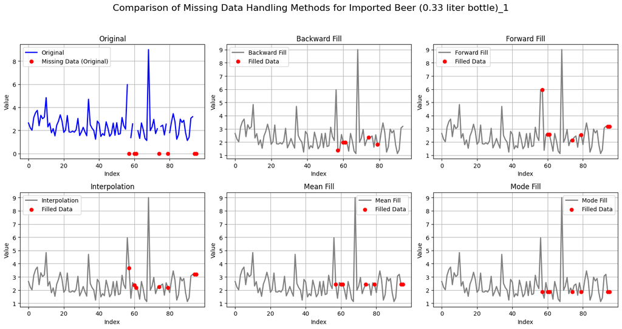

```python
import matplotlib.pyplot as plt

# Get the list of columns with missing values
columns_with_missing = [
    'Domestic Beer (0.5 liter draught)',
    'Imported Beer (0.33 liter bottle)',
    'Bottle of Wine (Mid-Range)',
    'Domestic Beer (0.5 liter bottle)',
    'Imported Beer (0.33 liter bottle)_1'
]

# Create a copy of the DataFrame
df_null = df.copy()

# Iterate over each column with missing values
for col in columns_with_missing:
    # Select the column with missing values
    col_data = df_null[col].copy()

    # Create columns with different NaN handling methods
    col_bfill = col_data.fillna(method='bfill')  # Backward fill
    col_ffill = col_data.fillna(method='ffill')  # Forward fill
    col_interpolation = col_data.interpolate(method='linear')  # Linear interpolation
    col_mean = col_data.fillna(col_data.mean())  # Fill with mean
    col_mode = col_data.fillna(col_data.mode()[0])  # Fill with mode

    # Create a list of methods and their corresponding labels
    methods = [
        ("Original", col_data),
        ("Backward Fill", col_bfill),
        ("Forward Fill", col_ffill),
        ("Interpolation", col_interpolation),
        ("Mean Fill", col_mean),
        ("Mode Fill", col_mode)
    ]

    # Create subplots: 2 rows, 3 columns (adjust as needed)
    fig, axes = plt.subplots(nrows=2, ncols=3, figsize=(15, 8))
    fig.suptitle(f"Comparison of Missing Data Handling Methods for {col}", fontsize=16)

    # Flatten axes for easier indexing
    axes = axes.flatten()

    # Plot each method in its own subplot
    for i, (label, method) in enumerate(methods):
        # Plot the method data
        axes[i].plot(method, linewidth=2, label=label, color='gray' if label != "Original" else 'blue')

        # Highlight missing data positions
        if label == "Original":
            # Red scatter points for missing data in the original column
            axes[i].scatter(method.index[method.isnull()], [0] * method.isnull().sum(), \
                            color='red', label='Missing Data (Original)', zorder=3)
        else:
            # Red scatter points where filling occurred
            missing_indices = col_data.isnull() & ~method.isnull()  # Locations where fill happened
            axes[i].scatter(missing_indices.index[missing_indices], method[missing_indices], \
                            color='red', label='Filled Data', zorder=3)

        # Add titles and labels
        axes[i].set_title(label)
        axes[i].set_xlabel('Index')
        axes[i].set_ylabel('Value')
        axes[i].grid(True)
        axes[i].legend()

    # Adjust layout to prevent overlap
    plt.tight_layout(rect=[0, 0, 1, 0.95])  # Leave space for suptitle
    plt.show();
```

Backward Fill (bfill): Fills the missing values with the next valid value in the column.

Forward Fill (ffill): Fills the missing values with the previous valid value in the column.

Linear Interpolation: Fills the missing values by linearly interpolating between the previous and next valid values.

Mean Fill: Fills the missing values with the mean (average) of the column.

Mode Fill: Fills the missing values with the most frequent (mode) value in the column.

```python
columns_to_interpolate = ['Domestic Beer (0.5 liter draught)',
    'Imported Beer (0.33 liter bottle)',
    'Bottle of Wine (Mid-Range)',
    'Domestic Beer (0.5 liter bottle)',
    'Imported Beer (0.33 liter bottle)_1']

# Apply linear interpolation
df[columns_to_interpolate] = df[columns_to_interpolate].interpolate(method='linear')
```

```python
#Display rows with missing values
df[df.isnull().any(axis = 1)] # .any(axis=1): Checks if any value in a row is missing
```

|  | Rank | Country | Meal, Inexpensive Restaurant | Meal for 2 People, Mid-range Restaurant, Three-course | McMeal at McDonalds (or Equivalent Combo Meal) | Domestic Beer (0.5 liter draught) | Imported Beer (0.33 liter bottle) | Coke/Pepsi (0.33 liter bottle) | Water (0.33 liter bottle) | Milk (regular), (1 liter) | Loaf of Fresh White Bread (500g) | Eggs (regular) (12) | Local Cheese (1kg) | Water (1.5 liter bottle) | Bottle of Wine (Mid-Range) | Domestic Beer (0.5 liter bottle) | Imported Beer (0.33 liter bottle)_1 | Cigarettes 20 Pack (Marlboro) | One-way Ticket (Local Transport) | Chicken Fillets (1kg) | Monthly Pass (Regular Price) | Gasoline (1 liter) | Volkswagen Golf 1.4 90 KW Trendline (Or Equivalent New Car) | Apartment (1 bedroom) in City Centre | Apartment (1 bedroom) Outside of Centre | Apartment (3 bedrooms) in City Centre | Apartment (3 bedrooms) Outside of Centre | Basic (Electricity, Heating, Cooling, Water, Garbage) for 85m2 Apartment | Internet (60 Mbps or More, Unlimited Data, Cable/ADSL) | … |
| --- | --- | --- | --- | --- | --- | --- | --- | --- | --- | --- | --- | --- | --- | --- | --- | --- | --- | --- | --- | --- | --- | --- | --- | --- | --- | --- | --- | --- | --- | --- |

```python
df.head(1)
```

|  | Rank | Country | Meal, Inexpensive Restaurant | Meal for 2 People, Mid-range Restaurant, Three-course | McMeal at McDonalds (or Equivalent Combo Meal) | Domestic Beer (0.5 liter draught) | Imported Beer (0.33 liter bottle) | Coke/Pepsi (0.33 liter bottle) | Water (0.33 liter bottle) | Milk (regular), (1 liter) | Loaf of Fresh White Bread (500g) | Eggs (regular) (12) | Local Cheese (1kg) | Water (1.5 liter bottle) | Bottle of Wine (Mid-Range) | Domestic Beer (0.5 liter bottle) | Imported Beer (0.33 liter bottle)_1 | Cigarettes 20 Pack (Marlboro) | One-way Ticket (Local Transport) | Chicken Fillets (1kg) | Monthly Pass (Regular Price) | Gasoline (1 liter) | Volkswagen Golf 1.4 90 KW Trendline (Or Equivalent New Car) | Apartment (1 bedroom) in City Centre | Apartment (1 bedroom) Outside of Centre | Apartment (3 bedrooms) in City Centre | Apartment (3 bedrooms) Outside of Centre | Basic (Electricity, Heating, Cooling, Water, Garbage) for 85m2 Apartment | Internet (60 Mbps or More, Unlimited Data, Cable/ADSL) | … |
| --- | --- | --- | --- | --- | --- | --- | --- | --- | --- | --- | --- | --- | --- | --- | --- | --- | --- | --- | --- | --- | --- | --- | --- | --- | --- | --- | --- | --- | --- | --- |
| 0 | 1 | Switzerland | 27.38 | 120.48 | 16.43 | 7.67 | 6.57 | 4.83 | 4.4 | 1.92 | 3.56 | 6.72 | 25.49 | 1.09 | 13.14 | 2.25 | 2.65 | 9.86 | 3.83 | 27.48 | 87.62 | 1.99 | 35925.44 | 1819.44 | 1526.46 | 3283.47 | 2713.62 | 240.34 | 53.54 | … |

```python
# #df.isnull().sum()
df.isnull().sum().sum()
```

```
0
```

### Duplicate Values

```python
df.duplicated().sum()
```

```
0
```

## Summary Statistics

### .describe()

```python
# df.describe().T
```

```python
df.select_dtypes('object', 'category').columns.to_list()
```

```
['Country']
```

```python
df1 = df.describe().T
df1['ratio'] = df1['std'] / df1['mean']
df1['skew'] = df1['std'] / df1['mean']
df1.sort_values(by='ratio', ascending=False)
```

|  | count | mean | std | min | 25% | 50% | 75% | max | ratio | skew |
| --- | --- | --- | --- | --- | --- | --- | --- | --- | --- | --- |
| Price per Square Meter to Buy Apartment in City Centre | 96.0 | 3698.489375 | 3904.248537 | 373.76 | 1556.1600 | 2438.035000 | 4526.5750 | 26702.10 | 1.055633 | 1.055633 |
| Price per Square Meter to Buy Apartment Outside of Centre | 96.0 | 2519.032604 | 2618.692969 | 260.32 | 1048.9975 | 1558.730000 | 3290.7200 | 16394.29 | 1.039563 | 1.039563 |
| Mortgage Interest Rate in Percentages (%), Yearly, for 20 Years Fixed-Rate | 96.0 | 9.007917 | 9.087537 | 1.84 | 4.4800 | 6.285000 | 10.3800 | 76.34 | 1.008839 | 1.008839 |
| Preschool (or Kindergarten), Full Day, Private, Monthly for 1 Child | 96.0 | 409.340729 | 412.128553 | 30.66 | 169.8500 | 311.595000 | 467.8200 | 2689.70 | 1.006811 | 1.006811 |
| Taxi 1hour Waiting (Normal Tariff) | 96.0 | 14.991042 | 14.595996 | 0.51 | 5.2250 | 10.000000 | 20.1425 | 75.57 | 0.973648 | 0.973648 |
| Average Monthly Net Salary (After Tax) | 96.0 | 1381.882708 | 1232.667031 | 34.45 | 482.4775 | 912.175000 | 2220.1475 | 6485.20 | 0.892020 | 0.892020 |
| One-way Ticket (Local Transport) | 96.0 | 1.134688 | 0.925378 | 0.15 | 0.3950 | 0.855000 | 1.5400 | 3.83 | 0.815535 | 0.815535 |
| Internet (60 Mbps or More, Unlimited Data, Cable/ADSL) | 96.0 | 31.742500 | 25.439937 | 5.73 | 16.9675 | 28.015000 | 38.1275 | 210.78 | 0.801447 | 0.801447 |
| Cigarettes 20 Pack (Marlboro) | 96.0 | 5.695312 | 4.472423 | 1.20 | 2.8850 | 4.335000 | 6.2975 | 28.48 | 0.785281 | 0.785281 |
| Water (0.33 liter bottle) | 96.0 | 1.048333 | 0.790966 | 0.13 | 0.3950 | 0.835000 | 1.5575 | 4.40 | 0.754498 | 0.754498 |
| Apartment (1 bedroom) Outside of Centre | 96.0 | 501.920208 | 371.241581 | 49.36 | 245.7325 | 374.595000 | 646.5925 | 1961.74 | 0.739643 | 0.739643 |
| Apartment (3 bedrooms) Outside of Centre | 96.0 | 883.992292 | 652.931965 | 131.58 | 443.4100 | 667.055000 | 1129.7675 | 3704.07 | 0.738617 | 0.738617 |
| Taxi Start (Normal Tariff) | 96.0 | 2.557083 | 1.853683 | 0.28 | 1.0675 | 2.160000 | 3.3725 | 10.51 | 0.724921 | 0.724921 |
| Apartment (3 bedrooms) in City Centre | 96.0 | 1222.958542 | 872.251283 | 221.25 | 698.3475 | 983.470000 | 1502.0925 | 5650.93 | 0.713230 | 0.713230 |
| Apartment (1 bedroom) in City Centre | 96.0 | 665.652396 | 459.513170 | 89.85 | 348.2275 | 530.385000 | 849.8425 | 2659.05 | 0.690320 | 0.690320 |
| Domestic Beer (0.5 liter draught) | 96.0 | 3.448021 | 2.305316 | 0.87 | 1.9975 | 2.566667 | 4.6300 | 11.69 | 0.668591 | 0.668591 |
| International Primary School, Yearly for 1 Child | 96.0 | 8288.244062 | 5530.049658 | 466.13 | 4873.3200 | 7479.500000 | 10746.3500 | 31238.27 | 0.667216 | 0.667216 |
| Monthly Pass (Regular Price) | 96.0 | 36.022604 | 23.837805 | 0.00 | 19.5550 | 30.860000 | 49.0800 | 102.86 | 0.661746 | 0.661746 |
| Basic (Electricity, Heating, Cooling, Water, Garbage) for 85m2 Apartment | 96.0 | 122.686458 | 78.474938 | 15.83 | 57.7950 | 103.445000 | 175.0700 | 345.81 | 0.639638 | 0.639638 |
| Taxi 1km (Normal Tariff) | 96.0 | 1.286458 | 0.822690 | 0.26 | 0.6800 | 1.085000 | 1.7525 | 4.27 | 0.639500 | 0.639500 |
| Coke/Pepsi (0.33 liter bottle) | 96.0 | 1.455104 | 0.895690 | 0.29 | 0.7300 | 1.265000 | 2.1300 | 4.83 | 0.615551 | 0.615551 |
| Mobile Phone Monthly Plan with Calls and 10GB+ Data | 96.0 | 18.485521 | 11.374710 | 2.31 | 10.1700 | 16.605000 | 23.2750 | 59.39 | 0.615331 | 0.615331 |
| Meal, Inexpensive Restaurant | 96.0 | 9.287917 | 5.492719 | 1.64 | 4.6275 | 8.515000 | 12.3400 | 27.38 | 0.591383 | 0.591383 |
| Rank | 96.0 | 48.500000 | 27.856777 | 1.00 | 24.7500 | 48.500000 | 72.2500 | 96.00 | 0.574367 | 0.574367 |
| Loaf of Fresh White Bread (500g) | 96.0 | 1.415104 | 0.785359 | 0.14 | 0.8225 | 1.315000 | 1.8700 | 3.61 | 0.554983 | 0.554983 |
| Tomato (1kg) | 96.0 | 2.251146 | 1.216508 | 0.40 | 1.3350 | 2.035000 | 3.0025 | 5.82 | 0.540395 | 0.540395 |
| Water (1.5 liter bottle) | 96.0 | 0.833958 | 0.447753 | 0.19 | 0.5400 | 0.710000 | 1.0825 | 2.43 | 0.536901 | 0.536901 |
| Apples (1kg) | 96.0 | 2.350521 | 1.197218 | 0.72 | 1.4350 | 2.185000 | 2.7925 | 7.07 | 0.509342 | 0.509342 |
| Potato (1kg) | 96.0 | 1.310833 | 0.666154 | 0.38 | 0.8375 | 1.125000 | 1.8000 | 3.51 | 0.508191 | 0.508191 |
| Imported Beer (0.33 liter bottle) | 96.0 | 4.019063 | 1.997934 | 1.29 | 2.5925 | 3.495000 | 4.8125 | 13.07 | 0.497114 | 0.497114 |
| Chicken Fillets (1kg) | 96.0 | 7.081979 | 3.519896 | 2.49 | 4.6675 | 6.555000 | 8.4800 | 27.48 | 0.497022 | 0.497022 |
| Meal for 2 People, Mid-range Restaurant, Three-course | 96.0 | 44.751458 | 22.140587 | 10.66 | 26.7025 | 41.070000 | 61.7200 | 120.48 | 0.494746 | 0.494746 |
| Onion (1kg) | 96.0 | 1.316667 | 0.638435 | 0.37 | 0.8800 | 1.150000 | 1.7250 | 3.07 | 0.484887 | 0.484887 |
| Volkswagen Golf 1.4 90 KW Trendline (Or Equivalent New Car) | 96.0 | 29458.463125 | 14057.455218 | 13973.06 | 22190.6350 | 27609.245000 | 33345.4875 | 131362.03 | 0.477196 | 0.477196 |
| Fitness Club, Monthly Fee for 1 Adult | 96.0 | 41.473229 | 19.775754 | 12.87 | 30.2575 | 38.780000 | 46.6550 | 115.38 | 0.476832 | 0.476832 |
| Oranges (1kg) | 96.0 | 1.991979 | 0.945888 | 0.38 | 1.4350 | 1.700000 | 2.3775 | 5.87 | 0.474848 | 0.474848 |
| Tennis Court Rent (1 Hour on Weekend) | 96.0 | 17.508646 | 8.219902 | 5.15 | 11.5075 | 15.785000 | 21.9575 | 42.30 | 0.469477 | 0.469477 |
| Cinema, International Release, 1 Seat | 96.0 | 8.104479 | 3.781369 | 1.00 | 5.1225 | 7.000000 | 10.5375 | 21.91 | 0.466578 | 0.466578 |
| Beef Round (1kg) (or Equivalent Back Leg Red Meat) | 96.0 | 12.028021 | 5.602467 | 4.01 | 8.9475 | 10.870000 | 13.9525 | 44.55 | 0.465785 | 0.465785 |
| Domestic Beer (0.5 liter bottle) | 96.0 | 1.749219 | 0.803852 | 0.72 | 1.1625 | 1.615000 | 2.0750 | 4.82 | 0.459549 | 0.459549 |
| Lettuce (1 head) | 96.0 | 1.174167 | 0.527705 | 0.22 | 0.7650 | 1.125000 | 1.4775 | 2.44 | 0.449430 | 0.449430 |
| Toyota Corolla Sedan 1.6l 97kW Comfort (Or Equivalent New Car) | 96.0 | 29155.037500 | 12623.066787 | 16181.05 | 23514.7125 | 26523.785000 | 32308.5475 | 118984.72 | 0.432963 | 0.432963 |
| Imported Beer (0.33 liter bottle)_1 | 96.0 | 2.447292 | 1.057032 | 1.13 | 1.8075 | 2.260000 | 2.8100 | 9.00 | 0.431919 | 0.431919 |
| Bottle of Wine (Mid-Range) | 96.0 | 9.316823 | 3.980326 | 4.25 | 6.1975 | 8.230000 | 11.5875 | 22.62 | 0.427219 | 0.427219 |
| Cappuccino (regular) | 96.0 | 2.801458 | 1.149917 | 0.59 | 1.8775 | 2.650000 | 3.5425 | 5.69 | 0.410471 | 0.410471 |
| Gasoline (1 liter) | 96.0 | 1.268333 | 0.510644 | 0.03 | 0.9300 | 1.310000 | 1.6025 | 3.13 | 0.402610 | 0.402610 |
| Local Cheese (1kg) | 96.0 | 9.725938 | 3.814612 | 3.37 | 7.4600 | 8.950000 | 12.2475 | 25.49 | 0.392210 | 0.392210 |
| Rice (white), (1kg) | 96.0 | 1.918333 | 0.740725 | 0.58 | 1.4175 | 1.870000 | 2.3150 | 4.58 | 0.386129 | 0.386129 |
| Eggs (regular) (12) | 96.0 | 2.642500 | 1.015024 | 0.96 | 1.9025 | 2.545000 | 3.3150 | 6.72 | 0.384115 | 0.384115 |
| 1 Pair of Jeans (Levis 501 Or Similar) | 96.0 | 60.440833 | 22.589212 | 15.33 | 43.6200 | 57.435000 | 80.0200 | 116.67 | 0.373741 | 0.373741 |
| Milk (regular), (1 liter) | 96.0 | 1.401146 | 0.512457 | 0.45 | 1.0575 | 1.310000 | 1.7000 | 3.10 | 0.365741 | 0.365741 |
| McMeal at McDonalds (or Equivalent Combo Meal) | 96.0 | 7.541250 | 2.531542 | 3.03 | 5.7650 | 7.455000 | 9.2600 | 16.43 | 0.335693 | 0.335693 |
| Banana (1kg) | 96.0 | 1.672500 | 0.523480 | 0.51 | 1.3275 | 1.615000 | 1.9125 | 3.23 | 0.312993 | 0.312993 |
| 1 Pair of Men Leather Business Shoes | 96.0 | 90.682917 | 27.679227 | 31.24 | 72.2500 | 91.910000 | 109.6100 | 172.26 | 0.305231 | 0.305231 |
| 1 Summer Dress in a Chain Store (Zara, H&M, ...) | 96.0 | 38.765625 | 9.665503 | 18.26 | 32.1625 | 38.560000 | 42.9450 | 75.86 | 0.249332 | 0.249332 |
| 1 Pair of Nike Running Shoes (Mid-Range) | 96.0 | 86.207500 | 17.863119 | 36.02 | 78.2225 | 86.900000 | 96.0600 | 138.76 | 0.207211 | 0.207211 |

**Cost of Living:**

- Urban areas (city centers) have significantly higher housing costs.
- Food and beverages (especially alcohol) can be premium-priced, while staples are stable across regions.
- Transportation costs are affordable with public transport, but car ownership remains expensive due to purchase costs.

**Income and Affordability:**

- Average monthly net salary varies significantly, affecting affordability in different regions.
- Leisure activities like cinema and fitness are more accessible than high-cost items like education or housing.

**Regional Variation:**

- The skew column indicates variability: lower skew suggests consistent pricing, while higher skew indicates regional disparity.

**Housing and Unilities**

- Price per Square Meter to Buy Apartment in City Centre
- Price per Square Meter to Buy Apartment Outside of Centre
- Apartment (1 bedroom) in City Centre
- Apartment (1 bedroom) Outside of Centre
- Apartment (3 bedrooms) in City Centre
- Apartment (3 bedrooms) Outside of Centre
- Basic (Electricity, Heating, Cooling, Water, Garbage) for 85m2 Apartment

Insights

- Housing prices in city centers higher than outside the city
- Price Variation: Apartments in city centers are much more expensive than those outside the city, with a mean price of $3698.49/m² in the city versus $2519.03/m² outside.
- Utilities show a wide variation, with higher bills in some areas indicating colder or more urban locations.
- Utility costs are generally low, with a mean of $122.69, but some areas can be very expensive, reaching $345.81.
- The ratio column suggests consistent pricing differences between city and non-city housing.
- Skew: Housing prices show positive skew, meaning a few outliers with extremely high prices are inflating the averages.

**Transportation**

- Taxi Start (Normal Tariff)
- Taxi 1km (Normal Tariff)
- Taxi 1hour Waiting (Normal Tariff)
- One-way Ticket (Local Transport)
- Monthly Pass (Regular Price)
- Gasoline (1 liter)
- Volkswagen Golf 1.4 90 KW Trendline (Or Equivalent New Car)
- Toyota Corolla Sedan 1.6l 97kW Comfort (Or Equivalent New Car)

Insights

**Food and Beverages**

- Meal, Inexpensive Restaurant
- Meal for 2 People, Mid-range Restaurant, Three-course
- McMeal at McDonald's (or Equivalent Combo Meal)
- Domestic Beer (0.5 liter draught)
- Imported Beer (0.33 liter bottle)
- Water (0.33 liter bottle)
- Coke/Pepsi (0.33 liter bottle)
- Milk (regular), (1 liter)
- Loaf of Fresh White Bread (500g)
- Eggs (regular) (12)
- Local Cheese (1kg)
- Chicken Fillets (1kg)
- Rice (white), (1kg)
- Banana (1kg)
- Tomato (1kg)
- Potato (1kg)
- Onion (1kg)
- Apples (1kg)
- Oranges (1kg)
- Bottle of Wine (Mid-Range)
- Cappuccino (regular)

Insights

**Clothing and Footwear**

- Pair of Jeans (Levis 501 Or Similar)
- Summer Dress in a Chain Store (Zara, H&M, ...)
- Pair of Nike Running Shoes (Mid-Range)
- Pair of Men Leather Business Shoes

Insights

**Leisure and Recreation**

- Tennis Court Rent (1 Hour on Weekend)
- Cinema, International Release, 1 Seat
- Fitness Club, Monthly Fee for 1 Adult
- Cappuccino (regular)

Insights

- Recreational activities like tennis court rental and fitness memberships have significant cost differences, potentially reflecting regional affluence.
- Coffee (cappuccino) prices are consistent but still show urban pricing trends.

**Education**

- Preschool (or Kindergarten), Full Day, Private, Monthly for 1 Child
- International Primary School, Yearly for 1 Child

Insights

- Education costs are highly variable, with international primary schools being one of the most expensive categories.
- Private preschools are moderately priced in comparison but still represent a significant expense for families.

### Category Info

```python
# data['Country'].value_counts()
```

## Exploratory Data Analysis (EDA)

### Univiariate Analysis

Select Columns Histogram and Boxplot

```python
import seaborn as sns
import matplotlib.pyplot as plt

# Function to plot a boxplot and a histogram along the same scale and print statistics
def histogram_boxplot(data, feature, figsize=(12, 7), kde=True, bins=None):
    """
    Boxplot and histogram combined with descriptive statistics and legend for key values.

    data: dataframe
    feature: dataframe column
    figsize: size of figure (default (12,7))
    kde: whether to show the density curve (default False)
    bins: number of bins for histogram (default None)
    """
    # Calculate descriptive statistics
    min_val = data[feature].min()
    max_val = data[feature].max()
    mean_val = data[feature].mean()
    median_val = data[feature].median()
    Q1 = data[feature].quantile(0.25)
    Q3 = data[feature].quantile(0.75)
    IQR = Q3 - Q1

    # Print the statistics
    print(f"Statistics for {feature}:")
    print(f"Min: {round(min_val, 2)}")
    print(f"Max: {round(max_val, 2)}")
    print(f"Mean: {round(mean_val, 2)}")
    print(f"Median (Q2): {round(median_val, 2)}")
    print(f"Q1 (25th percentile): {round(Q1, 2)}")
    print(f"Q3 (75th percentile): {round(Q3, 2)}")
    print(f"IQR (Q3 - Q1): {round(IQR, 2)}")
    print("-" * 40)

    # Plot the boxplot and histogram
    f2, (ax_box2, ax_hist2) = plt.subplots(
        nrows=2,        # Number of rows of the subplot grid = 2
        sharex=True,    # x-axis will be shared among all subplots
        gridspec_kw={"height_ratios": (0.25, 0.75)},
        figsize=figsize,
    )                   # Creating the 2 subplots

    sns.boxplot(data=data, x=feature, ax=ax_box2, showmeans=True, color="violet")  # Boxplot
    sns.histplot(
        data=data, x=feature, kde=kde, ax=ax_hist2, bins=bins, palette="winter"
    ) if bins else sns.histplot(data=data, x=feature, kde=kde, ax=ax_hist2)  # Histogram

    # Add vertical lines for min, max, mean, median, Q1, Q3
    ax_hist2.axvline(min_val, color="blue", linestyle=":", label="Min")
    ax_hist2.axvline(max_val, color="red", linestyle=":", label="Max")
    ax_hist2.axvline(mean_val, color="green", linestyle="--", label="Mean")
    ax_hist2.axvline(median_val, color="black", linestyle="-", label="Median (Q2)")
    ax_hist2.axvline(Q1, color="orange", linestyle="--", label="Q1 (25th percentile)")
    ax_hist2.axvline(Q3, color="purple", linestyle="--", label="Q3 (75th percentile)")

    # Add legend to the histogram
    ax_hist2.legend(loc="upper right", title="Statistics")

    # Show plot
    plt.show();
```

```
Statistics for Price per Square Meter to Buy Apartment in City Centre:
Min: 373.76
Max: 26702.1
Mean: 3698.49
Median (Q2): 2438.03
Q1 (25th percentile): 1556.16
Q3 (75th percentile): 4526.58
IQR (Q3 - Q1): 2970.42
----------------------------------------
```

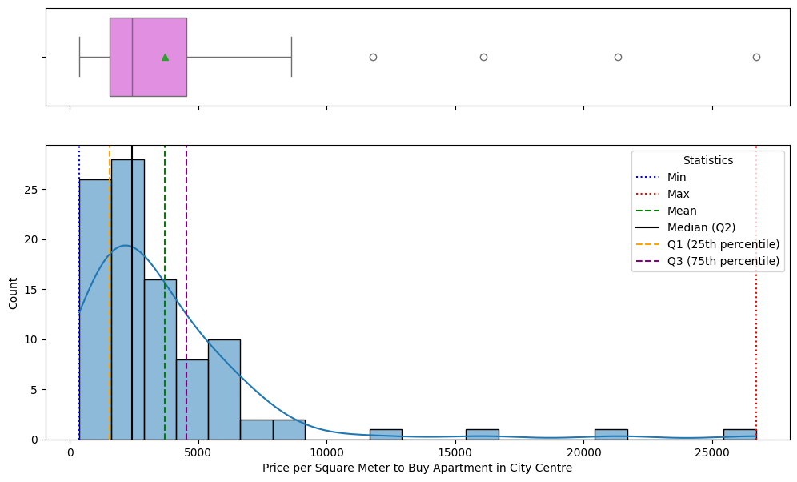

```python
histogram_boxplot(df, 'Price per Square Meter to Buy Apartment in City Centre')
```

Possible Insights

- separate dataset into difference price brackets to see distinct market segments
- Investigate if high priced outliers correspond to specific regions, amentities, or other factors.
- Investigate difference of outside of the City Centre

```
Statistics for Average Monthly Net Salary (After Tax):
Min: 34.45
Max: 6485.2
Mean: 1381.88
Median (Q2): 912.17
Q1 (25th percentile): 482.48
Q3 (75th percentile): 2220.15
IQR (Q3 - Q1): 1737.67
----------------------------------------
```

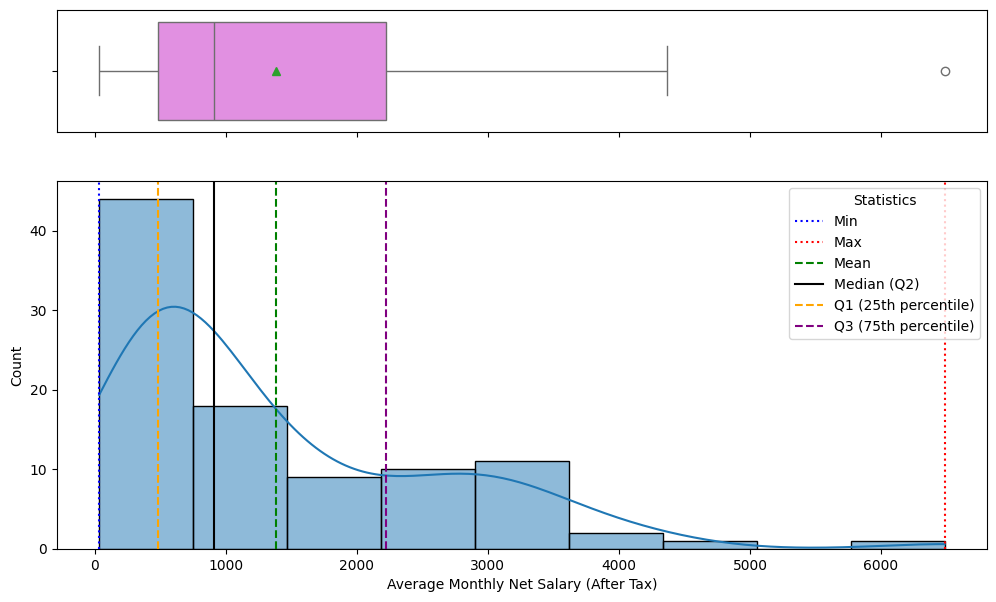

```python
histogram_boxplot(df, 'Average Monthly Net Salary (After Tax)')
```

- Min Salary: 34.45 – Represents extremely low income in some regions, possibly due to part-time or informal employment.
- Max Salary: 6,485.2 – Indicates high income, likely in regions with stronger economies or high-paying industries.
- Mean Salary: 1,381.88 – The average salary is pulled up by higher earners but remains relatively close to the middle range.
- Median (Q2): 912.17 – The central point where half the salaries are below this value. Lower than the mean, suggesting a right-skewed distribution.
- IQR (Q3 - Q1): 1,737.67 – Reflects significant variability in incomes within the middle 50% of the data.
- Q1 (25th Percentile): 482.48 – A quarter of the population earns less than this amount, indicating the lower income range.
- Q3 (75th Percentile): 2,220.15 – Three-quarters of the population earns less than this value, reflecting the upper income range.

Distribution:

- The right-skewed histogram indicates that most people earn on the lower end, with fewer individuals earning extremely high salaries.
- A high concentration of salaries falls below 1,000, as shown by the tall bars in the histogram. Outliers:

The boxplot shows one or two extreme outliers above 6,000, likely representing high-income earners in affluent regions or specialized industries.

Salary Brackets:

Insights for Analysis

- Income Inequality:
  - The significant skew and presence of outliers suggest notable income disparity between regions or individuals.
- Middle Class:
  - The IQR (1,737.67) highlights the spread of incomes in the middle class, showing variability across economic strata.
- High Earners' Influence:
  - The mean is significantly higher than the median, indicating the mean is inflated by high earners. Comparison Opportunity:

Compare income levels across regions or industries to identify areas of high productivity or economic disparity.

Actionable Recommendations

- Investigate the factors driving salaries below Q1 (482.48). Are these part-time jobs, rural areas, or underdeveloped economies? Outlier Analysis:
- Investigate high-income regions or individuals above Q3, particularly outliers beyond 6,000.
- Examine correlations between income and housing costs, education levels, or transportation to identify cost-of-living disparities.

```python
# histogram_boxplot(df, 'Apartment (1 bedroom) in City Centre')
```

```python
# histogram_boxplot(df, 'Basic (Electricity, Heating, Cooling, Water, Garbage) for 85m2 Apartment')
```

```python
# histogram_boxplot(df, 'Meal, Inexpensive Restaurant')
```

### Bivariate Analysis

Select Columns

```python
# # Exclude non-numeric columns
# numeric_data = df.select_dtypes(include=np.number)

# msk = np.triu(numeric_data.corr())

# # Create heatmap
# plt.figure(figsize=(15, 7))
# sns.heatmap(numeric_data.corr(), annot=True, vmin=-1, vmax=1, fmt=".2f", cmap="Spectral", mask = msk)
# plt.show();
```

```python
# # Function to plot stacked bar plots

# def stacked_barplot(data, predictor, target):
#     """
#     Print the category counts and plot a stacked bar chart

#     data: dataframe
#     predictor: independent variable
#     target: target variable
#     """
#     count = data[predictor].nunique()
#     sorter = data[target].value_counts().index[-1]
#     tab1 = pd.crosstab(data[predictor], data[target], margins = True).sort_values(
#         by = sorter, ascending = False
#     )
#     print(tab1)
#     print("-" * 120)
#     tab = pd.crosstab(data[predictor], data[target], normalize = "index").sort_values(
#         by = sorter, ascending = False
#     )
#     tab.plot(kind = "bar", stacked = True, figsize = (count + 1, 5))
#     plt.legend(
#         loc = "lower left",
#         frameon = False,
#     )
#     plt.legend(loc = "upper left", bbox_to_anchor = (1, 1))
#     plt.show();
```

```python
# stacked_barplot(df, "Meal, Inexpensive Restaurant", 'Rank');
```

```python
# stacked_barplot(df, "Meal, Inexpensive Restaurant", 'Rank');
```

```python
# stacked_barplot(df, "Meal, Inexpensive Restaurant", 'Rank');
```

```python
# stacked_barplot(df, "Meal, Inexpensive Restaurant", 'Rank');
```

```python
# stacked_barplot(df, "Meal, Inexpensive Restaurant", 'Rank');
```

## Data Preparation for Model Building

```python
# Creating dummy variables for the categorical columns
# drop_first=True is used to avoid redundant variables

df_encoded = pd.get_dummies(df, columns=['Country'], drop_first=True)
df_encoded.head(1)
```

|  | Rank | Meal, Inexpensive Restaurant | Meal for 2 People, Mid-range Restaurant, Three-course | McMeal at McDonalds (or Equivalent Combo Meal) | Domestic Beer (0.5 liter draught) | Imported Beer (0.33 liter bottle) | Coke/Pepsi (0.33 liter bottle) | Water (0.33 liter bottle) | Milk (regular), (1 liter) | Loaf of Fresh White Bread (500g) | Eggs (regular) (12) | Local Cheese (1kg) | Water (1.5 liter bottle) | Bottle of Wine (Mid-Range) | Domestic Beer (0.5 liter bottle) | Imported Beer (0.33 liter bottle)_1 | Cigarettes 20 Pack (Marlboro) | One-way Ticket (Local Transport) | Chicken Fillets (1kg) | Monthly Pass (Regular Price) | Gasoline (1 liter) | Volkswagen Golf 1.4 90 KW Trendline (Or Equivalent New Car) | Apartment (1 bedroom) in City Centre | Apartment (1 bedroom) Outside of Centre | Apartment (3 bedrooms) in City Centre | Apartment (3 bedrooms) Outside of Centre | Basic (Electricity, Heating, Cooling, Water, Garbage) for 85m2 Apartment | Internet (60 Mbps or More, Unlimited Data, Cable/ADSL) | Mobile Phone Monthly Plan with Calls and 10GB+ Data | … |
| --- | --- | --- | --- | --- | --- | --- | --- | --- | --- | --- | --- | --- | --- | --- | --- | --- | --- | --- | --- | --- | --- | --- | --- | --- | --- | --- | --- | --- | --- | --- |
| 0 | 1 | 27.38 | 120.48 | 16.43 | 7.67 | 6.57 | 4.83 | 4.4 | 1.92 | 3.56 | 6.72 | 25.49 | 1.09 | 13.14 | 2.25 | 2.65 | 9.86 | 3.83 | 27.48 | 87.62 | 1.99 | 35925.44 | 1819.44 | 1526.46 | 3283.47 | 2713.62 | 240.34 | 53.54 | 48.88 | … |

```python
# Separating independent variables and the target variable
x = df_encoded.drop('Rank', axis = 1)

y = df_encoded['Rank']

print('df', df.shape)
print('df_encoded', df_encoded.shape)
print('x: ', x.shape)
print('y: ', y.shape)
```

```
df (96, 57)
df_encoded (96, 151)
x:  (96, 150)
y:  (96,)
```

```python
# Splitting the dataset into train and test datasets

from sklearn.model_selection import train_test_split, cross_val_score, KFold

x_train, x_test, y_train, y_test = train_test_split(x, y, test_size = 0.3, shuffle = True, random_state = 1)
```

```python
# Checking the shape of the train and test data

#x_train.shape, x_test.shape

# Checking the shape of the train and test data
print("Shape of Training set : ", x_train.shape)
print("Shape of test set : ", x_test.shape)
```

```
Shape of Training set :  (67, 150)
Shape of test set :  (29, 150)
```

```python
top_10_original = df[['Rank', 'Country']].head(10)
top_10_original
```

|  | Rank | Country |
| --- | --- | --- |
| 0 | 1 | Switzerland |
| 1 | 2 | Denmark |
| 2 | 3 | Belgium |
| 3 | 4 | Israel |
| 4 | 5 | United States |
| 5 | 6 | Norway |
| 6 | 7 | Netherlands |
| 7 | 8 | Ireland |
| 8 | 9 | United Kingdom |
| 9 | 10 | Canada |

## Model Building

- We will be using different metrics functions defined in sklearn like RMSE, MAE, 𝑅2, Adjusted 𝑅2, and MAPE for regression model evaluation. We will define a function to calculate these metrics.
- The mean absolute percentage error (MAPE) measures the accuracy of predictions as a percentage and can be calculated as the average absolute percentage error for all data points. The absolute percentage error is defined as the predicted value minus actual value divided by actual value. It works best if there are no extreme values in the data and none of the actual values are 0.

```python
# Function to compute adjusted R-squared
def adj_r2_score(predictors, targets, predictions):
    r2 = r2_score(targets, predictions)
    n = predictors.shape[0]
    k = predictors.shape[1]
    return 1 - ((1 - r2) * (n - 1) / (n - k - 1))


# Function to compute MAPE
def mape_score(targets, predictions):
    return np.mean(np.abs(targets - predictions) / targets) * 100


# Function to compute different metrics to check performance of a regression model
def model_performance_regression(model, predictors, target):
    """
    Function to compute different metrics to check regression model performance

    model: regressor
    predictors: independent variables
    target: dependent variable
    """

    pred = model.predict(predictors)                  # Predict using the independent variables
    r2 = r2_score(target, pred)                       # To compute R-squared
    adjr2 = adj_r2_score(predictors, target, pred)    # To compute adjusted R-squared
    rmse = np.sqrt(mean_squared_error(target, pred))  # To compute RMSE
    mae = mean_absolute_error(target, pred)           # To compute MAE
    mape = mape_score(target, pred)                   # To compute MAPE

    # Creating a dataframe of metrics
    df_perf = pd.DataFrame(
        {
            "RMSE": rmse,
            "MAE": mae,
            "R-squared": r2,
            "Adj. R-squared": adjr2,
            "MAPE": mape,
        },
        index=[0],
    )

    return df_perf
```

### Decision Trees

- find the tree that provides the best predictions on the training data, while also being as simple and interpretable as possible
- used for both classification and regression tasks
- splitting the dataset into smaller subsets based on the feature that provides the most information gain at each step

```python
# find the tree that provides the best predictions on the training data, while also being as simple and interpretable as possible.

from sklearn.tree import DecisionTreeRegressor

# Decision Tree Regressor
dt_regressor = DecisionTreeRegressor(random_state = 1)

# fitting the model
dt_regressor.fit(x_train, y_train)
```

```
DecisionTreeRegressor(random_state=1)
```

```python
from sklearn.metrics import make_scorer,mean_squared_error, r2_score, mean_absolute_error

# Model Performance on the test data, i.e., prediction

dt_regressor_perf_test = model_performance_regression(dt_regressor, x_test, y_test)

dt_regressor_perf_test
```

|  | RMSE | MAE | R-squared | Adj. R-squared | MAPE |
| --- | --- | --- | --- | --- | --- |
| 0 | 4.250761 | 3.448276 | 0.970722 | 1.00672 | 8.637442 |

#### Decision Tree Visualization

Find best max_depth hyperparameter

```python
from sklearn.tree import DecisionTreeRegressor
from sklearn.model_selection import GridSearchCV
from sklearn.metrics import mean_squared_error, mean_absolute_error, r2_score
import pandas as pd
import numpy as np

# Function to compute adjusted R-squared
def adj_r2_score(x_test, y_test, y_pred):
    r2 = r2_score(y_test, y_pred)
    n = len(y_test)  # Number of samples
    k = x_test.shape[1]  # Number of predictors
    return 1 - ((1 - r2) * (n - 1) / (n - k - 1))

# Function to compute MAPE
def mape_score(y_test, y_pred):
    return np.mean(np.abs((y_test - y_pred) / y_test)) * 100

# Parameter grid
param_grid = {
    "max_depth": [3, 5, 10, None],
    "min_samples_split": [2, 5, 10, 20],
    "min_samples_leaf": [1, 5, 10, 20],
    "max_features": [None, "sqrt", "log2", 0.5],
    "max_leaf_nodes": [None, 10, 20, 50],
    "min_impurity_decrease": [0.0, 0.01, 0.1],
}

# Decision Tree Regressor
dt_regressor = DecisionTreeRegressor(random_state=1)

# GridSearchCV
grid_search = GridSearchCV(
    estimator=dt_regressor,
    param_grid=param_grid,
    scoring="neg_mean_squared_error",
    cv=5,
    verbose=1,
    n_jobs=-1,
)

# Fit the model
grid_search.fit(x_train, y_train)

# Best parameters
print("Best Parameters:", grid_search.best_params_)

# Best model
best_dt_regressor = grid_search.best_estimator_

# Evaluate on test set
y_pred = best_dt_regressor.predict(x_test)

# Compute metrics
mse = mean_squared_error(y_test, y_pred)
mae = mean_absolute_error(y_test, y_pred)
r2 = r2_score(y_test, y_pred)
adj_r2 = adj_r2_score(x_test, y_test, y_pred)
mape = mape_score(y_test, y_pred)

# Create a dataframe for metrics and ranking
metrics_df = pd.DataFrame({
    "Metric": ["MSE", "MAE", "R^2", "Adjusted R^2", "MAPE"],
    "Value": [mse, mae, r2, adj_r2, mape],
    "Rank (Lower is Better for Errors)": [1 / mse, 1 / mae, r2, adj_r2, -mape]  # Adjust rank logic for each metric
})

# Rank metrics
metrics_df.sort_values(by="Rank (Lower is Better for Errors)", ascending=False, inplace=True)

# Output metrics
print("\nMetrics and Rankings:")
print(metrics_df)
```

```
Fitting 5 folds for each of 3072 candidates, totalling 15360 fits
Best Parameters: {'max_depth': 5, 'max_features': None, 'max_leaf_nodes': 20, 'min_impurity_decrease': 0.0, 'min_samples_leaf': 1, 'min_samples_split': 5}

Metrics and Rankings:
         Metric      Value  Rank (Lower is Better for Errors)
3  Adjusted R^2   1.014108                           1.014108
2           R^2   0.938531                           0.938531
1           MAE   4.991379                           0.200345
0           MSE  37.935584                           0.026360
4          MAPE  27.040087                         -27.040087
```

```python
# from sklearn import tree
# features = list(x.columns)

# # Building the model with max_depth=3
# dt_regressor_visualize = DecisionTreeRegressor(random_state = 1, max_depth = 5) # 5 for example

# # fitting the model
# dt_regressor_visualize.fit(x_train, y_train)
```

Re-implement Decision Tree

```python
from sklearn import tree
features = list(x.columns)

# Building the model with the best parameters from GridSearchCV
dt_regressor_visualize = DecisionTreeRegressor(
    random_state=1,
    max_depth=5,
    max_features=None,
    max_leaf_nodes=20,
    min_impurity_decrease=0.0,
    min_samples_leaf=1,
    min_samples_split=5
)

# Fitting the model
dt_regressor_visualize.fit(x_train, y_train)
```

```
DecisionTreeRegressor(max_depth=5, max_leaf_nodes=20, min_samples_split=5,
                      random_state=1)
```

```python
# Evaluate the model performance on the test data
dt_tuned_test_performance = model_performance_regression(dt_regressor_visualize, x_test, y_test)

# Print the performance metrics
print(dt_tuned_test_performance)
```

```
       RMSE       MAE  R-squared  Adj. R-squared       MAPE
0  6.159187  4.991379   0.938531        1.014108  27.040087
```

Visualization

Insights

- Follow a path from the root to a leaf node:
  - To interpret a decision tree, you can follow a path from the root node to a leaf node. Along the path, you can see the tests performed on the features, and based on the test results, the data is split into smaller subsets.
- Analyze the feature importance:
  - You can analyze the feature importance by looking at the splits in the tree. The features used to split the data at the top of the tree are the most important features, as they have the highest impact on the decision.
- Analyze the class distribution:
  - You can analyze the class distribution at the leaf nodes to understand how the decision tree predicts the class labels. If the majority of the samples in a leaf node belong to a particular class, the decision tree predicts that class for the new data.
- Explain the decision:
  - Finally, you can explain the decision made by the decision tree by summarizing the path taken from the root to the leaf node and the class label predicted at the leaf node. You can also explain the importance of the features used in the decision and how they influence the final prediction.

[figure not shown]

```python
plt.figure(figsize = (20,20))
tree.plot_tree(dt_regressor_visualize, feature_names = features, filled = True, fontsize = 12, node_ids = True, class_names = None)
plt.show();
```

Text Visualization

```python
print(tree.export_text(dt_regressor_visualize, feature_names = x_train.columns.tolist(), show_weights = True))
```

```
|--- Meal, Inexpensive Restaurant <= 8.93
|   |--- Meal, Inexpensive Restaurant <= 4.80
|   |   |--- Meal, Inexpensive Restaurant <= 3.28
|   |   |   |--- Meal, Inexpensive Restaurant <= 2.14
|   |   |   |   |--- value: [94.00]
|   |   |   |--- Meal, Inexpensive Restaurant >  2.14
|   |   |   |   |--- Eggs (regular) (12) <= 2.14
|   |   |   |   |   |--- value: [88.50]
|   |   |   |   |--- Eggs (regular) (12) >  2.14
|   |   |   |   |   |--- value: [84.00]
|   |   |--- Meal, Inexpensive Restaurant >  3.28
|   |   |   |--- Toyota Corolla Sedan 1.6l 97kW Comfort (Or Equivalent New Car) <= 26973.30
|   |   |   |   |--- 1 Pair of Jeans (Levis 501 Or Similar) <= 43.80
|   |   |   |   |   |--- value: [76.50]
|   |   |   |   |--- 1 Pair of Jeans (Levis 501 Or Similar) >  43.80
|   |   |   |   |   |--- value: [73.00]
|   |   |   |--- Toyota Corolla Sedan 1.6l 97kW Comfort (Or Equivalent New Car) >  26973.30
|   |   |   |   |--- value: [81.67]
|   |--- Meal, Inexpensive Restaurant >  4.80
|   |   |--- Meal, Inexpensive Restaurant <= 6.76
|   |   |   |--- Preschool (or Kindergarten), Full Day, Private, Monthly for 1 Child <= 278.91
|   |   |   |   |--- value: [69.00]
|   |   |   |--- Preschool (or Kindergarten), Full Day, Private, Monthly for 1 Child >  278.91
|   |   |   |   |--- value: [63.00]
|   |   |--- Meal, Inexpensive Restaurant >  6.76
|   |   |   |--- Taxi 1hour Waiting (Normal Tariff) <= 7.12
|   |   |   |   |--- value: [48.75]
|   |   |   |--- Taxi 1hour Waiting (Normal Tariff) >  7.12
|   |   |   |   |--- Taxi 1hour Waiting (Normal Tariff) <= 12.78
|   |   |   |   |   |--- value: [57.00]
|   |   |   |   |--- Taxi 1hour Waiting (Normal Tariff) >  12.78
|   |   |   |   |   |--- value: [53.00]
|--- Meal, Inexpensive Restaurant >  8.93
|   |--- Meal, Inexpensive Restaurant <= 14.78
|   |   |--- Meal, Inexpensive Restaurant <= 10.35
|   |   |   |--- Water (1.5 liter bottle) <= 1.06
|   |   |   |   |--- value: [43.00]
|   |   |   |--- Water (1.5 liter bottle) >  1.06
|   |   |   |   |--- value: [36.67]
|   |   |--- Meal, Inexpensive Restaurant >  10.35
|   |   |   |--- Meal, Inexpensive Restaurant <= 12.21
|   |   |   |   |--- value: [29.25]
|   |   |   |--- Meal, Inexpensive Restaurant >  12.21
|   |   |   |   |--- One-way Ticket (Local Transport) <= 1.44
|   |   |   |   |   |--- value: [25.00]
|   |   |   |   |--- One-way Ticket (Local Transport) >  1.44
|   |   |   |   |   |--- value: [22.00]
|   |--- Meal, Inexpensive Restaurant >  14.78
|   |   |--- Apartment (1 bedroom) in City Centre <= 1040.03
|   |   |   |--- Milk (regular), (1 liter) <= 1.33
|   |   |   |   |--- value: [17.50]
|   |   |   |--- Milk (regular), (1 liter) >  1.33
|   |   |   |   |--- value: [13.50]
|   |   |--- Apartment (1 bedroom) in City Centre >  1040.03
|   |   |   |--- Local Cheese (1kg) <= 12.34
|   |   |   |   |--- value: [8.00]
|   |   |   |--- Local Cheese (1kg) >  12.34
|   |   |   |   |--- value: [3.00]
```

### Bagging Regressor (Bootstrap Aggregating)

- ensemble learning technique that involves training multiple models on different subsets of the training data and then combining their predictions. - The idea is to reduce variance and overfitting by averaging the predictions of many models
- training multiple regression models (e.g., Decision Trees) on different subsets of the training data and then combining their predictions by taking the average
- reduce the variance and overfitting of the final model, while still maintaining the same bias as a single model trained on the entire dataset

```python
from sklearn.ensemble import RandomForestRegressor,BaggingRegressor

# Bagging Regressor
bagging_estimator = BaggingRegressor(random_state = 1)

# fitting the model
bagging_estimator.fit(x_train, y_train)
```

```
BaggingRegressor(random_state=1)
```

```python
# Model Performance on the test data
bagging_estimator_perf_test = model_performance_regression(bagging_estimator, x_test, y_test)

bagging_estimator_perf_test
```

|  | RMSE | MAE | R-squared | Adj. R-squared | MAPE |
| --- | --- | --- | --- | --- | --- |
| 0 | 3.014391 | 2.237931 | 0.985277 | 1.003379 | 14.993493 |

### Random Forest Regressor

- combines multiple Decision Trees to create a more robust and accurate model
- training multiple models on different subsets of the training data
- each split in the tree, only a random subset of the available features is considered for splitting
- training multiple Decision Trees on different subsets of the training data, and then combining their predictions by taking their average

```python
# Random Forest Regressor
rf_regressor = RandomForestRegressor(n_estimators = 100, random_state = 1)

# fitting the model
rf_regressor.fit(x_train, y_train)
```

```
RandomForestRegressor(random_state=1)
```

```python
# Model Performance on the test data
rf_regressor_perf_test = model_performance_regression(rf_regressor, x_test, y_test)

rf_regressor_perf_test
```

|  | RMSE | MAE | R-squared | Adj. R-squared | MAPE |
| --- | --- | --- | --- | --- | --- |
| 0 | 3.152638 | 2.210345 | 0.983895 | 1.003696 | 15.608317 |

### AdaBoost (Adaptive Boosting)

- combines multiple weak classifiers to create a stronger classifier
  - weak classifier is a classifier that performs only slightly better than random guessing
- raining multiple weak classifiers on different subsets of the training data, and then combining their predictions to make a final prediction

```python
# Importing AdaBoost Regressor
from sklearn.ensemble import AdaBoostRegressor

# AdaBoost Regressor
ada_regressor = AdaBoostRegressor(random_state=1)

# Fitting the model
ada_regressor.fit(x_train, y_train)
```

```
AdaBoostRegressor(random_state=1)
```

```python
# Model Performance on the test data
ada_regressor_perf_test = model_performance_regression(ada_regressor, x_test, y_test)

ada_regressor_perf_test
```

|  | RMSE | MAE | R-squared | Adj. R-squared | MAPE |
| --- | --- | --- | --- | --- | --- |
| 0 | 3.282661 | 2.222134 | 0.982539 | 1.004007 | 17.084816 |

### Gradient Boosting Regressor

- combines multiple weak learners to create a strong learner.
- adding weak learners to the model and updating the weights of the training examples based on the residual errors of the previous models
- focus on the examples that were not well predicted by the previous model and improve its overall accuracy.
- computing the negative gradient of the loss function with respect to the predicted values and using it to update the model.

```python
# Importing Gradient Boosting Regressor
from sklearn.ensemble import GradientBoostingRegressor

# Gradient Boosting Regressor
grad_regressor = GradientBoostingRegressor(random_state=1)

# Fitting the model
grad_regressor.fit(x_train, y_train)
```

```
GradientBoostingRegressor(random_state=1)
```

```python
# Model Performance on the test data
grad_regressor_perf_test = model_performance_regression(grad_regressor, x_test, y_test)

grad_regressor_perf_test
```

|  | RMSE | MAE | R-squared | Adj. R-squared | MAPE |
| --- | --- | --- | --- | --- | --- |
| 0 | 2.372516 | 1.791953 | 0.990879 | 1.002093 | 11.836328 |

### XGBoost (Extreme Gradient Boosting) Regressor

- optimized implementation of the Gradient Boosting algorithm
- adding weak learners to the model and updating the weights of the training examples based on the residual errors of the previous models
- Additional Features
  - Regularization: XGBoost includes L1 and L2 regularization to prevent overfitting
  - Tree Pruning: XGBoost includes a technique called "tree pruning" to remove irrelevant features and reduce the complexity of the model
- involves computing the negative gradient of the loss function with respect to the predicted values and using it to update the model

```python
# Installing the xgboost library using the 'pip' command
!pip install xgboost
```

```python
# Importing XGBoost Regressor
from xgboost import XGBRegressor

# XGBoost Regressor
xgb = XGBRegressor(random_state = 1)

# Fitting the model
xgb.fit(x_train,y_train)

# Model Performance on the test data
xgb_perf_test = model_performance_regression(xgb, x_test, y_test)

xgb_perf_test
```

|  | RMSE | MAE | R-squared | Adj. R-squared | MAPE |
| --- | --- | --- | --- | --- | --- |
| 0 | 1.905898 | 1.497554 | 0.994114 | 1.001351 | 10.386577 |

## Models' Performance Comparison

```python
models_test_comp_df = pd.concat(
    [
        dt_regressor_perf_test.T,
        dt_tuned_test_performance.T,
        bagging_estimator_perf_test.T,
        rf_regressor_perf_test.T,
        ada_regressor_perf_test.T,
        grad_regressor_perf_test.T,
        xgb_perf_test.T
    ],
    axis = 1,
)

models_test_comp_df.columns = [
    "Decision tree regressor",
    "Decision tree tuned",
    "Bagging Regressor",
    "Random Forest regressor",
    "Ada Boost Regressor",
    "Gradient Boosting Regressor",
    "XG Boost Regressor"]

print("Test performance comparison:")

models_test_comp_df.T
```

```
Test performance comparison:
```

|  | RMSE | MAE | R-squared | Adj. R-squared | MAPE |
| --- | --- | --- | --- | --- | --- |
| Decision tree regressor | 4.250761 | 3.448276 | 0.970722 | 1.006720 | 8.637442 |
| Decision tree tuned | 6.159187 | 4.991379 | 0.938531 | 1.014108 | 27.040087 |
| Bagging Regressor | 3.014391 | 2.237931 | 0.985277 | 1.003379 | 14.993493 |
| Random Forest regressor | 3.152638 | 2.210345 | 0.983895 | 1.003696 | 15.608317 |
| Ada Boost Regressor | 3.282661 | 2.222134 | 0.982539 | 1.004007 | 17.084816 |
| Gradient Boosting Regressor | 2.372516 | 1.791953 | 0.990879 | 1.002093 | 11.836328 |
| XG Boost Regressor | 1.905898 | 1.497554 | 0.994114 | 1.001351 | 10.386577 |

### Choosing the Models for Tuning Hyperparameters

Choosing the final model from the set of compared models depends on various factors. Here are some steps to help you make a decision:

- **Look at the evaluation metrics**: Check the evaluation metrics of the models that you have compared. Choose the model that performs the best based on your criteria. However, it is important to keep in mind that the model with the best performance on the training set may not necessarily be the best on the test set. Therefore, it is important to also consider the model's performance on the test set.
- **Overfitting**: Check for overfitting in the models. A model that overfits the data may perform very well on the training set but poorly on the test set. One way to check for overfitting is by comparing the performance of the model on the training set and the test set. If the difference in performance is large, it may indicate overfitting. Therefore, it is better to choose a model that has a good balance between performance on the training set and the test set.
- **Model complexity**: Consider the complexity of the models. A more complex model may fit the data better but may also overfit the data. Therefore, it is better to choose a model that has a good balance between simplicity and performance.
- **Interpretability**: Consider the interpretability of the models. Some models, such as decision trees, are more interpretable than others, such as neural networks. If interpretability is important for your application, it may be better to choose a more interpretable model.
- **Runtime**: Consider the runtime of the models. Some models may take longer to train and predict than others. If runtime is a concern, it may be better to choose a model that is faster to train and predict.

```python
# Creating a ranking system based on the rules
ranking = models_test_comp_df.T.copy()

# Ranking by each metric (ascending for lowest is best, descending for higher is better)
ranking['RMSE Rank'] = ranking['RMSE'].rank(ascending=True)
ranking['MAE Rank'] = ranking['MAE'].rank(ascending=True)
ranking['R-squared Rank'] = ranking['R-squared'].rank(ascending=False)
ranking['Adj. R-squared Rank'] = ranking['Adj. R-squared'].rank(ascending=False)
ranking['MAPE Rank'] = ranking['MAPE'].rank(ascending=True)

# Adding a total rank by summing the individual ranks (lower total rank is better)
ranking['Total Rank'] = (
    ranking['RMSE Rank'] +
    ranking['MAE Rank'] +
    ranking['R-squared Rank'] +
    ranking['Adj. R-squared Rank'] +
    ranking['MAPE Rank']
)

# Sorting by the total rank
ranking = ranking.sort_values(by='Total Rank')

print("Ranked Test Performance Comparison:")
ranking
```

```
Ranked Test Performance Comparison:
```

|  | RMSE | MAE | R-squared | Adj. R-squared | MAPE | RMSE Rank | MAE Rank | R-squared Rank | Adj. R-squared Rank | MAPE Rank | Total Rank |
| --- | --- | --- | --- | --- | --- | --- | --- | --- | --- | --- | --- |
| XG Boost Regressor | 1.905898 | 1.497554 | 0.994114 | 1.001351 | 10.386577 | 1.0 | 1.0 | 1.0 | 7.0 | 2.0 | 12.0 |
| Gradient Boosting Regressor | 2.372516 | 1.791953 | 0.990879 | 1.002093 | 11.836328 | 2.0 | 2.0 | 2.0 | 6.0 | 3.0 | 15.0 |
| Bagging Regressor | 3.014391 | 2.237931 | 0.985277 | 1.003379 | 14.993493 | 3.0 | 5.0 | 3.0 | 5.0 | 4.0 | 20.0 |
| Random Forest regressor | 3.152638 | 2.210345 | 0.983895 | 1.003696 | 15.608317 | 4.0 | 3.0 | 4.0 | 4.0 | 5.0 | 20.0 |
| Decision tree regressor | 4.250761 | 3.448276 | 0.970722 | 1.006720 | 8.637442 | 6.0 | 6.0 | 6.0 | 2.0 | 1.0 | 21.0 |
| Ada Boost Regressor | 3.282661 | 2.222134 | 0.982539 | 1.004007 | 17.084816 | 5.0 | 4.0 | 5.0 | 3.0 | 6.0 | 23.0 |
| Decision tree tuned | 6.159187 | 4.991379 | 0.938531 | 1.014108 | 27.040087 | 7.0 | 7.0 | 7.0 | 1.0 | 7.0 | 29.0 |

- RMSE: lowest is best
- MAE: lowest is best
- R-squared: higher is better
- Adjusted R-squeared: higher is better
- MAPE: lowest is best

XG Boost Regressor is the best model

## Tuning the Model

Tuning the hyperparameters of a machine learning model can help improve its performance. Here are some steps you can follow to tune the hyperparameters of your model:

- Identify the hyperparameters: Before tuning the hyperparameters, it's important to identify the hyperparameters that can be tuned. In the case of the models you have built (Decision Trees, Bagging Regressor, Random Forest, AdaBoost, Gradient Boosting, XGBoost), some of the hyperparameters that can be tuned include the number of estimators, learning rate, maximum depth, minimum sample split, etc.
- Determine the range of values for each hyperparameter: Once you have identified the hyperparameters, you need to determine the range of values that each hyperparameter can take. For example, you can set the range for the number of estimators to be between 50 and 200.
- Choose a method to search for the best hyperparameters: There are different methods for searching for the best hyperparameters, such as grid search and randomized search. Grid search is a simple and exhaustive method that involves evaluating the model performance for all possible combinations of hyperparameters within the specified range. Randomized search is similar to grid search, but instead of evaluating all possible combinations, it evaluates a random subset of combinations.
- Train and evaluate the model with each combination of hyperparameters: Once you have chosen a method to search for the best hyperparameters, you need to train and evaluate the model with each combination of hyperparameters within the specified range.
- Select the hyperparameters that give the best performance: Finally, you need to select the hyperparameters that give the best performance on the validation set. You can then use these hyperparameters to train the model on the full training set and evaluate its performance on the test set.

Overall, tuning the hyperparameters of a model can be a time-consuming process, but it can greatly improve the performance of the model.

### Tuned XG Boost Regressor

Options: GridSearchCV (time-consuming) and RandomizedSearchCV

#### GridSearchCV

```python
# import tensorflow as tf

# # Importing required libraries
# from sklearn.model_selection import GridSearchCV

# # XGBoost Regressor
# xgb_tuned = XGBRegressor(random_state=1)

# # Grid of parameters to choose from
# xgb_parameters = {
#     "n_estimators": [50, 100, 200],  # Number of trees
#     "max_depth": [3, 5, 7, 10],  # Maximum depth of the tree
#     "learning_rate": [0.01, 0.05, 0.1, 0.2],  # Step size shrinkage
#     "subsample": [0.6, 0.8, 1.0],  # Subsample ratio
#     "gamma": [0, 0.1, 0.5, 1],  # Minimum loss reduction
#     "colsample_bytree": [0.5, 0.7, 1.0],  # Fraction of features used per tree
#     "min_child_weight": [1, 5, 10],  # Minimum sum of weights in a leaf node
#     "reg_alpha": [0, 0.1, 1],  # L1 regularization term
#     "reg_lambda": [0, 0.1, 1],  # L2 regularization term
#     "tree_method": ["auto", "hist", "gpu_hist"],  # Tree-building algorithm
#     "booster": ["gbtree", "dart"],  # Booster type
#     "max_bin": [256, 512, 1024],  # Maximum bins for histogram-based splits
#     "grow_policy": ["depthwise", "lossguide"],  # Tree growth policy
#     "early_stopping_rounds": [10, 20],  # Early stopping rounds
#     "n_jobs": [-1],  # Use all available CPU cores
# }

# # Run the grid search
# xgb_grid_obj = GridSearchCV(
#     xgb_tuned, xgb_parameters, scoring="neg_mean_squared_error", cv=5
# )

# xgb_grid_obj = xgb_grid_obj.fit(x_train, y_train)

# # Set the xgb_tuned_regressor to the best combination of parameters
# xgb_tuned_regressor = xgb_grid_obj.best_estimator_

# xgb_tuned_regressor.fit(x_train, y_train)

# # Model Performance on the test data
# xgb_tuned_GridSearchCV_test = model_performance_regression(
#     xgb_tuned_regressor, x_test, y_test
# )

# xgb_tuned_GridSearchCV_test
```

#### RandomizedSearchCV

```python
# Importing required libraries
from sklearn.model_selection import RandomizedSearchCV
from scipy.stats import randint, uniform

# Define the XGBRegressor
xgb_tuned = XGBRegressor(random_state=1)

# Define the parameter distributions for randomized search
xgb_parameters = {
    "n_estimators": randint(50, 200),  # Number of trees
    "max_depth": [3, 5, 7, 10],  # Maximum depth of the tree
    "learning_rate": uniform(0.01, 0.3),  # Step size shrinkage
    "subsample": uniform(0.6, 0.4),  # Subsample ratio
    "colsample_bytree": uniform(0.6, 0.4),  # Subsample ratio of columns
    "gamma": uniform(0, 0.5),  # Minimum loss reduction for split
    "reg_alpha": uniform(0, 0.5),  # L1 regularization term
    "reg_lambda": uniform(0.5, 1.0),  # L2 regularization term
}

# Run the randomized search
xgb_random_search = RandomizedSearchCV(
    xgb_tuned,
    param_distributions=xgb_parameters,
    n_iter=20,  # Number of iterations
    scoring='neg_mean_squared_error',  # Scoring metric
    cv=5,  # Number of cross-validation folds
    random_state=1,
    n_jobs=-1  # Use all processors
)

# Fit the randomized search on training data
xgb_random_search.fit(x_train, y_train)

# Get the best estimator
xgb_tuned_regressor = xgb_random_search.best_estimator_

# Fit the model with the best parameters
xgb_tuned_regressor.fit(x_train, y_train)

# Evaluate model performance on the test data
xgb_tuned_RandomizedSearchCV_test = model_performance_regression(
    xgb_tuned_regressor,
    x_test,
    y_test
)

xgb_tuned_RandomizedSearchCV_test
```

|  | RMSE | MAE | R-squared | Adj. R-squared | MAPE |
| --- | --- | --- | --- | --- | --- |
| 0 | 2.323461 | 1.899173 | 0.991253 | 1.002008 | 10.37147 |

## Choosing the Final Model Raked

```python
# Concatenate performance metrics for all models
models_test_comp_df = pd.concat(
    [
        dt_regressor_perf_test.T,
        dt_tuned_test_performance.T,
        bagging_estimator_perf_test.T,
        rf_regressor_perf_test.T,
        ada_regressor_perf_test.T,
        grad_regressor_perf_test.T,
        xgb_perf_test.T,
        #xgb_tuned_GridSearchCV_test.T,
        xgb_tuned_RandomizedSearchCV_test.T,
    ],
    axis=1,
)

# Assign column names for clarity
models_test_comp_df.columns = [
    "Decision Tree Regressor",
    "Decision Tree tuned",
    "Bagging Regressor",
    "Random Forest Regressor",
    "Ada Boost Regressor",
    "Gradient Boosting Regressor",
    "XGBoost Regressor",
    #"XGBoost Tuned Regressor GridSearchCV",
    "XGBoost Tuned Regressor RandomizedSearchCV",
]

# Ensure all necessary metrics are present
# If Adjusted R-squared is missing, calculate it (if possible)
if 'Adjusted R-squared' not in models_test_comp_df.index:
    n = len(y_test)  # Number of samples in the test set
    p = x_test.shape[1]  # Number of predictors (features)
    models_test_comp_df.loc['Adjusted R-squared'] = 1 - (
        (1 - models_test_comp_df.loc['R-squared']) * (n - 1) / (n - p - 1)
    )

# Rank each metric
# RMSE, MAE, MAPE: Lower is better
models_test_comp_df.loc['RMSE_Rank'] = models_test_comp_df.loc['RMSE'].rank(ascending=True)
models_test_comp_df.loc['MAE_Rank'] = models_test_comp_df.loc['MAE'].rank(ascending=True)
models_test_comp_df.loc['MAPE_Rank'] = models_test_comp_df.loc['MAPE'].rank(ascending=True)

# R-squared, Adjusted R-squared: Higher is better
models_test_comp_df.loc['R2_Rank'] = models_test_comp_df.loc['R-squared'].rank(ascending=False)
models_test_comp_df.loc['Adjusted_R2_Rank'] = models_test_comp_df.loc['Adjusted R-squared'].rank(ascending=False)

# Calculate overall rank (sum of individual ranks)
models_test_comp_df.loc['Overall_Rank'] = (
    models_test_comp_df.loc['RMSE_Rank'] +
    models_test_comp_df.loc['MAE_Rank'] +
    models_test_comp_df.loc['MAPE_Rank'] +
    models_test_comp_df.loc['R2_Rank'] +
    models_test_comp_df.loc['Adjusted_R2_Rank']
).rank(ascending=True)

# Sort models by their overall rank
sorted_models = models_test_comp_df.T.sort_values(by='Overall_Rank')

# Display ranked model performance comparison
print("Ranked Model Performance Comparison:")
sorted_models
```

```
Ranked Model Performance Comparison:
```

|  | RMSE | MAE | R-squared | Adj. R-squared | MAPE | Adjusted R-squared | RMSE_Rank | MAE_Rank | MAPE_Rank | R2_Rank | Adjusted_R2_Rank | Overall_Rank |
| --- | --- | --- | --- | --- | --- | --- | --- | --- | --- | --- | --- | --- |
| XGBoost Regressor | 1.905898 | 1.497554 | 0.994114 | 1.001351 | 10.386577 | 1.001351 | 1.0 | 1.0 | 3.0 | 1.0 | 8.0 | 1.0 |
| XGBoost Tuned Regressor RandomizedSearchCV | 2.323461 | 1.899173 | 0.991253 | 1.002008 | 10.371470 | 1.002008 | 2.0 | 3.0 | 2.0 | 2.0 | 7.0 | 2.0 |
| Gradient Boosting Regressor | 2.372516 | 1.791953 | 0.990879 | 1.002093 | 11.836328 | 1.002093 | 3.0 | 2.0 | 4.0 | 3.0 | 6.0 | 3.0 |
| Decision Tree Regressor | 4.250761 | 3.448276 | 0.970722 | 1.006720 | 8.637442 | 1.006720 | 7.0 | 7.0 | 1.0 | 7.0 | 2.0 | 5.0 |
| Bagging Regressor | 3.014391 | 2.237931 | 0.985277 | 1.003379 | 14.993493 | 1.003379 | 4.0 | 6.0 | 5.0 | 4.0 | 5.0 | 5.0 |
| Random Forest Regressor | 3.152638 | 2.210345 | 0.983895 | 1.003696 | 15.608317 | 1.003696 | 5.0 | 4.0 | 6.0 | 5.0 | 4.0 | 5.0 |
| Ada Boost Regressor | 3.282661 | 2.222134 | 0.982539 | 1.004007 | 17.084816 | 1.004007 | 6.0 | 5.0 | 7.0 | 6.0 | 3.0 | 7.0 |
| Decision Tree tuned | 6.159187 | 4.991379 | 0.938531 | 1.014108 | 27.040087 | 1.014108 | 8.0 | 8.0 | 8.0 | 8.0 | 1.0 | 8.0 |

## Visualizing the Feature Importance

XGBoost Regressor was still the best algorythm

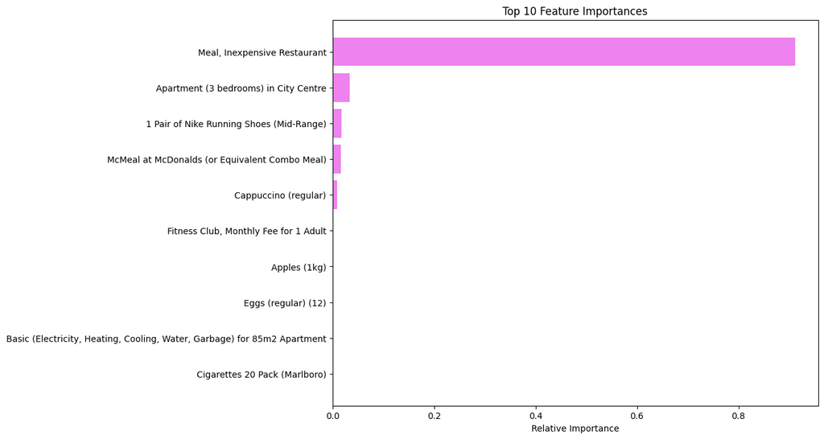

```python
# Get feature importances
features = list(x.columns)
importances = xgb.feature_importances_

# Get indices of the top 10 features (sorted in descending order of importance)
top_10_indices = np.argsort(importances)[-10:]  # Last 10 indices for top features

# Plotting the top 10 feature importances
plt.figure(figsize=(10, 8))
plt.title('Top 10 Feature Importances')

# Use top 10 indices to plot
plt.barh(range(len(top_10_indices)), importances[top_10_indices], color='violet', align='center')
plt.yticks(range(len(top_10_indices)), [features[i] for i in top_10_indices])
plt.xlabel('Relative Importance')

plt.show();
```

The most important features sorted

The rest of the variables have little or no influence on the rankings in this model.

## Rank Countries

```python
# Predict ranks for the entire dataset
df['Predicted Rank'] = xgb.predict(x)

# Sort countries by predicted rank
ranked_countries = df[['Country', 'Predicted Rank']].sort_values(by='Predicted Rank', ascending=True)

# Display top-ranked countries
print("Top Countries:")
print(ranked_countries.head(10))
```

```
Top Countries:
          Country  Predicted Rank
0     Switzerland        1.001215
1         Denmark        2.000195
3          Israel        3.999936
4   United States        4.999994
5          Norway        6.000108
6     Netherlands        6.999953
7         Ireland        8.000048
2         Belgium        8.933016
8  United Kingdom        9.000519
9          Canada        9.999697
```

Original Rank of Countries from Data source

```python
ranked_countries = df[['Country', 'Predicted Rank']].sort_values(by='Predicted Rank', ascending=True)

# Round the 'Predicted Rank' column to the nearest integer
ranked_countries['Predicted Rank'] = ranked_countries['Predicted Rank'].round(0).astype(int)

# Select the top 10 countries
top_10_new = ranked_countries.head(10)

# Display the result
top_10_new
```

|  | Country | Predicted Rank |
| --- | --- | --- |
| 0 | Switzerland | 1 |
| 1 | Denmark | 2 |
| 3 | Israel | 4 |
| 4 | United States | 5 |
| 5 | Norway | 6 |
| 6 | Netherlands | 7 |
| 7 | Ireland | 8 |
| 2 | Belgium | 9 |
| 8 | United Kingdom | 9 |
| 9 | Canada | 10 |

```python
top_10_original
```

|  | Rank | Country |
| --- | --- | --- |
| 0 | 1 | Switzerland |
| 1 | 2 | Denmark |
| 2 | 3 | Belgium |
| 3 | 4 | Israel |
| 4 | 5 | United States |
| 5 | 6 | Norway |
| 6 | 7 | Netherlands |
| 7 | 8 | Ireland |
| 8 | 9 | United Kingdom |
| 9 | 10 | Canada |

```python
# Merge the predicted and original ranks on 'Country'
comparison_df = pd.merge(
    ranked_countries.head(10),
    df[['Rank', 'Country']].head(10),
    on="Country",
    how="inner"
)

# Calculate the difference between predicted and original ranks
#comparison_df['Difference'] = comparison_df['Predicted Rank'] - comparison_df['Rank']

# Display the comparison
print("Comparison of Predicted and Original Ranks:")
print(comparison_df)
```

```
Comparison of Predicted and Original Ranks:
          Country  Predicted Rank  Rank
0     Switzerland        1.001215     1
1         Denmark        2.000195     2
2          Israel        3.999936     4
3   United States        4.999994     5
4          Norway        6.000108     6
5     Netherlands        6.999953     7
6         Ireland        8.000048     8
7         Belgium        8.933016     3
8  United Kingdom        9.000519     9
9          Canada        9.999697    10
```

## Business Insights and Recommendations

```python
# Get feature importances from the XGBoost model
features = list(x.columns)
importances = xgb.feature_importances_

# Combine features and their importance into a list of tuples
top_10_features_with_importance = list(zip(features, importances))

# Sort them in descending order of importance
top_10_features_with_importance.sort(key=lambda x: x[1], reverse=True)

# Print the top 10 features with their importance
print("Top 10 Features in Descending Order of Importance:\n")
for feature, importance in top_10_features_with_importance[:10]:
    print(f"{feature}: {importance:.4f}")
```

```
Top 10 Features in Descending Order of Importance:

Meal, Inexpensive Restaurant: 0.9112
Apartment (3 bedrooms) in City Centre: 0.0339
1 Pair of Nike Running Shoes (Mid-Range): 0.0182
McMeal at McDonalds (or Equivalent Combo Meal): 0.0166
Cappuccino (regular): 0.0087
Fitness Club, Monthly Fee for 1 Adult: 0.0014
Apples (1kg): 0.0012
Eggs (regular) (12): 0.0011
Basic (Electricity, Heating, Cooling, Water, Garbage) for 85m2 Apartment: 0.0010
Cigarettes 20 Pack (Marlboro): 0.0010
```

```python
# Merge original and predicted rankings on 'Country'
comparison_df = pd.merge(
    top_10_original,  # Original rankings
    top_10_new,       # Predicted rankings
    on="Country",
    how="inner"
)

# Rename columns for clarity
comparison_df.rename(columns={"Rank": "Original Rank", "Predicted Rank": "Predicted Rank"}, inplace=True)

# Display the comparison
comparison_df
```

|  | Original Rank | Country | Predicted Rank |
| --- | --- | --- | --- |
| 0 | 1 | Switzerland | 1 |
| 1 | 2 | Denmark | 2 |
| 2 | 3 | Belgium | 9 |
| 3 | 4 | Israel | 4 |
| 4 | 5 | United States | 5 |
| 5 | 6 | Norway | 6 |
| 6 | 7 | Netherlands | 7 |
| 7 | 8 | Ireland | 8 |
| 8 | 9 | United Kingdom | 9 |
| 9 | 10 | Canada | 10 |

## Conclusion and Recommendations

Insights

- Dominant Feature: "Meal, Inexpensive Restaurant" (Importance: 0.9112):
  - This feature overwhelmingly influences the model's predictions.
  - The affordability of meals at inexpensive restaurants appears to be the most critical factor when evaluating the countries.
- Significant but Secondary Feature: "Apartment (3 bedrooms) in City Centre" (Importance: 0.0339):
  - Housing costs in city centers play a role, albeit much smaller than inexpensive meal costs.
  - People are likely concerned about housing affordability when making decisions.
- Other Moderate Influencers:
  - Features such as the cost of Nike Running Shoes, McMeal at McDonald's, and Cappuccino reflect lifestyle and convenience-related expenses that hold some weight in decision-making.
- Minimal Impact Features:
  - Features like basic utilities, eggs, and cigarettes have negligible importance, suggesting that these are less of a concern for decision-makers or are relatively stable across countries.

Recommendations

- Targeted Marketing Strategies:
  - Focus on promoting affordable meal options in inexpensive restaurants, as this is the most influential factor for consumers. Highlight competitive advantages in affordable dining through campaigns targeted at tourists or expatriates.
- Urban Development Initiatives:
  - Since housing costs in city centers are a significant secondary factor, urban planners and policymakers should explore solutions to make city-center living more affordable.
- Lifestyle Branding:
  - Incorporate features like sports shoes, fast food, and coffee costs into branding strategies, emphasizing affordability and convenience.
- Decision-Making Models for Businesses:
  - Businesses looking to expand or attract customers should use this ranking to evaluate regions or countries based on inexpensive meal availability and housing affordability.
- Market Analysis:
  - Focus competitive research on meal affordability and housing costs to determine how to position offerings to capture demand.

Conclusion

```python
# google

path_ipynb = '/content/drive/MyDrive/My DS DA/Cost of Living Country Comparison/DS_SupervisedLearning_Regression_Decision_etc_Cost_of_Living_Comparison.ipynb'
notebook_path = path_ipynb

!jupyter nbconvert --to html "{notebook_path}"

from google.colab import files
path_html = '/content/drive/MyDrive/My DS DA/Cost of Living Country Comparison/DS_SupervisedLearning_Regression_Decision_etc_Cost_of_Living_Comparison.html'

files.download(path_html)
```

```
[NbConvertApp] Converting notebook /content/drive/MyDrive/My DS DA/Cost of Living Country Comparison/DS_SupervisedLearning_Regression_Decision_etc_Cost_of_Living_Comparison.ipynb to html
[NbConvertApp] WARNING | Alternative text is missing on 9 image(s).
[NbConvertApp] Writing 2494153 bytes to /content/drive/MyDrive/My DS DA/Cost of Living Country Comparison/DS_SupervisedLearning_Regression_Decision_etc_Cost_of_Living_Comparison.html
```